# Workshop 3: Probability

# 2. Probability Functions

How then do we use probability in our statistical analyses of risk, performance, and other systems engineering concepts?

Probability allows us to measure for any statistic (or parameter) `mu`, how **extreme** is that statistic? This is called *type II error*, measured by a `p`-value, the probability that a **more** extreme value occurred than our statistic. It’s an extremely helpful benchmark. In order to evaluate how **extreme** it is, we need values to compare it to. We can do this using (1) an observed distribution, (2) making a probability function curve of the observed distribution, or (3) assuming the probability function of a hypothetical distribution.

## 2.1 Example: Observed Distributions

[figure not shown]

Figure 6. Your Local ER

For example, a local hospital wants to make their health care services more affordable, given the surge in inflation.

- They measured `n = 15` patients who stayed 1 night over the last 7 days, how much were they charged (before insurance)? Let’s call this vector `obs` (for ‘observed data’).
- A 16th patient received a bill of `$3000` (above the national mean of ~`$2500`). We’ll record this as `stat` below.

```r
# Let's record our vector of 15 patients
obs <- c(1126, 1493, 1528, 1713, 1912, 2060, 2541, 2612, 2888, 2915, 3166, 3552, 3692, 3695, 4248)
# And let's get our new patient data point to compare against
stat <- 3000
```

Here, we know the full observed distribution of values (`cost`), so we can directly compute the `p_value` from them, using the logical operator `>=`.

```r
# Which values of in vector obs were greater than or equal to stat?
obs >= stat
```

```
##  [1] FALSE FALSE FALSE FALSE FALSE FALSE FALSE FALSE FALSE FALSE  TRUE  TRUE  TRUE  TRUE  TRUE
```

`R` interprets `TRUE == 1` & `FALSE == 0`, so we can take the `mean()` to get the percentage of values in `obs` greater than or equal to `stat`.

```r
# Get p-value, the probability of getting a value greater than or equal to stat
mean(obs >= stat)
```

```
## [1] 0.3333333
```

```r
# This means Total Probability, where probability of each cost is 1/n
sum(  (obs >= stat) / length(obs)   )
```

```
## [1] 0.3333333
```

Unfortunately, this only takes into account the exact values we observed (eg. $1493), but it can’t tell us anything about values we *didn’t* observe (eg. $1500). But logically, we know that the probability of getting a bill of $1500 should be pretty similar to a bill of $1493. So how do we fill in the gaps?

## 2.2 Observed Probability Density Functions

Above, we calculated the probability of getting a **more** extreme hospital bill based on a limited sample of points, but for more *precise* probabilities, we need to fill in the gaps between our observed data points.

- For a vector `x`, the probability density function is a **curve** providing the probability (`y`) of each value across the range of `x`.
- It shows the **relative frequency** (probability) of each *possible* value in the range.

We can ask R to estimate the probability density function for any observed vector using `density()`. This returns the density (`y`) of a bunch of hypothetical values (`x`) matching our distribution’s curve. We can access those results using the `broom` package, by `tidy()`-ing it into a data.frame.

```r
obs %>% density() %>% tidy() %>% tail(3)
```

```
## # A tibble: 3 × 2
##       x           y
##   <dbl>       <dbl>
## 1 5715. 0.000000725
## 2 5727. 0.000000675
## 3 5739. 0.000000628
```

But that’s *data*, not a *function*, right? Functions are *equations*, machines you can pump an input into to get a specific output. Given a data.frame of 2 vectors, `R` can actually approximate the `function` (equation) connecting vector 1 to vector 2 using `approxfun()`, *creating your own function!* So cool!

```r
# Let's make dobs(), the probability density function for our observed data.
dobs <- obs %>% density() %>% tidy() %>% approxfun()
# Now let's get a sequence (seq()) of costs from 1000 to 3000, in units of 1000....
seq(1000, 3000, by = 1000)
```

```
## [1] 1000 2000 3000
```

```r
# and let's feed it a range of data to get the frequencies at those costs!
seq(1000, 3000, by = 1000) %>% dobs()
```

```
## [1] 0.0001505136 0.0003081445 0.0003186926
```

For now, let’s get the densities for costs ranging from the min to the max observed cost.

```r
mypd <- tibble(
  # Get sequence from min to max, in units of $10
  cost = seq(min(obs), max(obs), by = 10),
  # Get probability densities
  prob_cost_i = dobs(cost)) %>%
  # Classify each row as TRUE (1) if cost greater than or equal to stat, or FALSE (0) if not.
  # This is the probability that each row is extreme (1 or 0)
  mutate(prob_extreme_i = cost >= stat)
# Check it out!
mypd %>% head(3)
```

```
## # A tibble: 3 × 3
##    cost prob_cost_i prob_extreme_i
##   <dbl>       <dbl> <lgl>
## 1  1126    0.000186 FALSE
## 2  1136    0.000189 FALSE
## 3  1146    0.000191 FALSE
```

- We’ll save it to `mypd`, naming the x-axis `cost` and the y-axis `prob_cost_i`, to show the probability of each `cost` in row `i` (eg. $1126, $1136, $1146, … `n`).
- We’ll also calculate `prob_extreme_i`, the probability that each *ith* `cost` is extreme (greater than or equal to our 16th patient’s bill). Either it *is* extreme (`TRUE == 100% = 1`) or it *isn’t* (`FALSE == 0% == 0`).

Our density function `dobs()` estimated `prob_cost_i` (`y`), the probability/relative frequency of `cost` (`x`) occurring, where `x` represents every possible value of `cost`.

- We can visualize `mypd` using `geom_area()` or `geom_line()` in `ggplot2`!
- We can add `geom_vline()` to draw a vertical line at the location of `stat` on the `xintercept`.

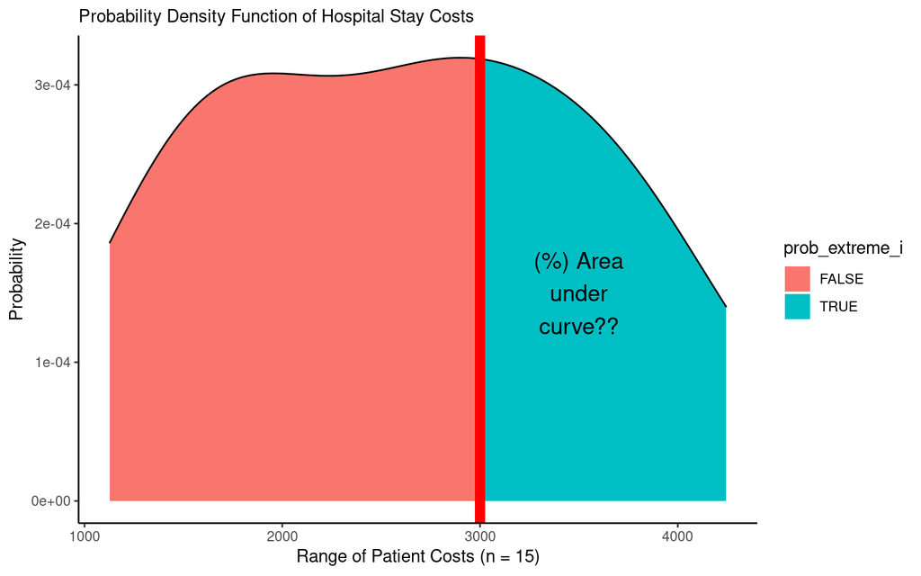

Figure 7. Visualizing a Probability Density Function!

```r
mypd %>%
  ggplot(mapping = aes(x = cost, y = prob_cost_i, fill = prob_extreme_i)) +
  # Fill in the area from 0 to y along x
  geom_area() +
  # Or just draw curve with line
  geom_line() +
  # add vertical line
  geom_vline(xintercept = stat, color = "red", size = 3) +
  # Add theme and labels
  theme_classic() +
  labs(x = "Range of Patient Costs (n = 15)",
       y = "Probability",
       subtitle = "Probability Density Function of Hospital Stay Costs") +
  # And let's add a quick label
  annotate("text", x = 3500, y = 1.5e-4, label = "(%) Area\nunder\ncurve??", size = 5)
```

## 2.3 Applying Probability Density Functions

Great! We can *view* the probability density function now above. But how do we translate that into **a single probability** that measures how extreme Patient 16’s bill is?

- We have the probability `prob_cost_i` at points `cost` estimated by the probability density function saved in `mypd`.
- We can calculate the total probability or `p_value` that a value of `cost` will be greater than our statistic `stat`, using our total probability formula. We can even restate it, so that it looks a little more like the weighted average it truly is.

$$P_{\ Extreme} = \sum_{i = 1}^{n}{ P
(Cost | Extreme_{\ i}) \times P (Cost_{\ i}) } = \frac{ \sum_{i =
1}^{n}{ P (Cost_{i}) \times P(Extreme)_{\ i} } }{ \sum_{i = 1}^{n}{
P(Cost_{i}) } }$$

```r
p <- mypd %>%
  # Calculate the conditional probability of each cost occurring given that condition
  mutate(prob_cost_extreme_i = prob_cost_i * prob_extreme_i) %>%
  # Next, let's summarize these probabilities
  summarize(
    # Add up all probabilities of each cost given its condition in row i
    prob_cost_extreme = sum(prob_cost_extreme_i),
    # Add up all probabilities of each cost in any row i
    prob_cost = sum(prob_cost_i),
    # Calculate the weighted average, or total probability of getting an extreme cost
    # by dividing these two sums!
    prob_extreme = prob_cost_extreme / prob_cost)
# Check it out!
p
```

```
## # A tibble: 1 × 3
##   prob_cost_extreme prob_cost prob_extreme
##               <dbl>     <dbl>        <dbl>
## 1            0.0317    0.0868        0.365
```

Very cool! Visually, what’s happening here?

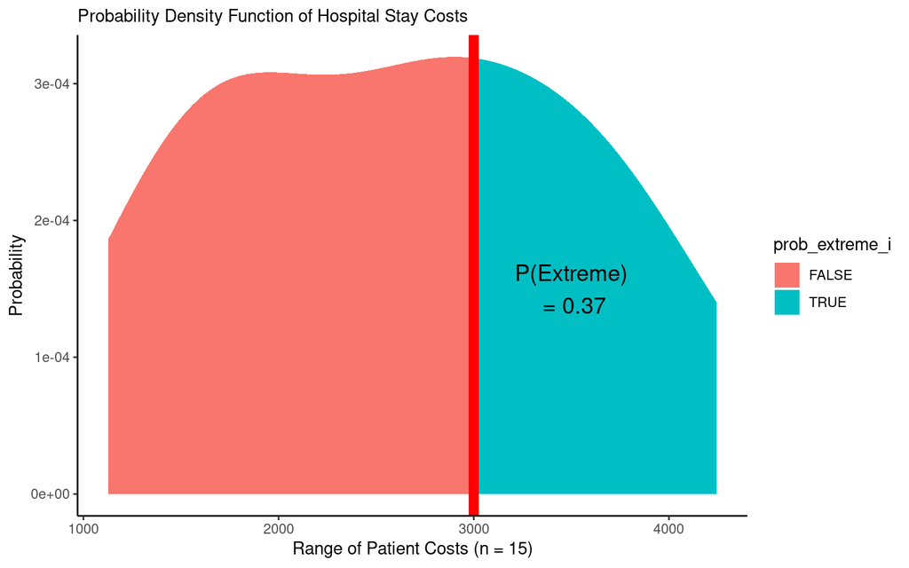

Figure 8. PDF with Area Under Curve!

```r
ggplot() +
  geom_area(data = mypd, mapping = aes(x = cost, y = prob_cost_i, fill = prob_extreme_i)) +
  geom_vline(xintercept = stat, color = "red", size = 3) +
  theme_classic() +
  labs(x = "Range of Patient Costs (n = 15)",
       y = "Probability",
       subtitle = "Probability Density Function of Hospital Stay Costs") +
  annotate("text", x = 3500, y = 1.5e-4,
           label = paste("P(Extreme)", "\n", " = ", p$prob_extreme %>% round(2), sep = ""),
           size = 5)
```

## 2.4 Observed Cumulative Distribution Functions

Alternatively, we can calculate that `p`-value for `prob_extreme` a different way, by looking at the **cumulative probability**.

- To add a values/probabilities in a vector together sequentially, we can use `cumsum()` (short for cumulative sum). For example:

```r
# Normally
c(1:5)
```

```
## [1] 1 2 3 4 5
```

```r
# Cumulatively summed
c(1:5) %>% cumsum()
```

```
## [1]  1  3  6 10 15
```

```r
# Same as
c(1, 2+1, 3+2+1, 4+3+2+1, 5+4+3+2+1)
```

```
## [1]  1  3  6 10 15
```

Every **probability density function (PDF)** can *also* be represented as a **cumulative distribution function (CDF)**. Here, we calculate the *cumulative* total probability of receiving *each* `cost`, applying `cumsum()` to the probability (`prob_cost`) of each value (`cost`). In this case, we’re basically saying, we’re interested in *all* the `costs`, so don’t discount any.

$$P_{\ Extreme} = \sum_{i = 1}^{n}{ P
(Cost | Extreme_{\ i} = 1) \times P (Cost_{\ i}) } = \frac{ \sum_{i =
1}^{n}{ P (Cost_{i}) \times 1 } }{ \sum_{i = 1}^{n}{ P(Cost_{i})
} }$$

```r
mypd %>%
  # For instance, we can do the first step here,
  # taking the cumulative probability of costs i through j....
  mutate(prob_cost_cumulative = cumsum(prob_cost_i)) %>%
  head(3)
```

```
## # A tibble: 3 × 4
##    cost prob_cost_i prob_extreme_i prob_cost_cumulative
##   <dbl>       <dbl> <lgl>                         <dbl>
## 1  1126    0.000186 FALSE                      0.000186
## 2  1136    0.000189 FALSE                      0.000375
## 3  1146    0.000191 FALSE                      0.000566
```

Our `prob_cost_cumulative` in row 3 above shows the total probability of `n = 3` patients receiving a cost of 1126 OR 1136 OR 1146. But, we want an *average* estimate for 1 patient. So, like in a weighted average, we can divide by the total probability of *all* (`n`) hypothetical patients in the probability density function receiving any of these costs. This gives us our *revised* `prob_cost_cumulative`, which ranges from `0` to `1`!

```r
mycd <- mypd %>%
  # For instance, we can do the first step here,
  # taking the cumulative probability of costs i through j....
  mutate(prob_cost_cumulative = cumsum(prob_cost_i) / sum(prob_cost_i)) %>%
  # We can also then identify the segment that is extreme!
  mutate(prob_extreme = prob_cost_cumulative * prob_extreme_i)

# Take a peek at the tail!
mycd %>% tail(3)
```

```
## # A tibble: 3 × 5
##    cost prob_cost_i prob_extreme_i prob_cost_cumulative prob_extreme
##   <dbl>       <dbl> <lgl>                         <dbl>        <dbl>
## 1  4226    0.000144 TRUE                          0.997        0.997
## 2  4236    0.000142 TRUE                          0.998        0.998
## 3  4246    0.000140 TRUE                          1            1
```

Let’s visualize `mycd`, our cumulative probabilities!

```r
viz_cd <- ggplot() +
  # Show the cumulative probability of each cost,
  # shaded by whether it is "extreme" (cost >= stat)  or not
  geom_area(data = mycd, mapping = aes(x = cost, y = prob_cost_cumulative, fill = prob_extreme_i)) +
  # Show cumulative probability of getting an extreme cost
  geom_area(data = mycd, mapping = aes(x = cost, y = prob_extreme, fill = prob_extreme_i))  +
  # Show the 16th patient's cost
  geom_vline(xintercept = stat, color = "red", size = 3) +
  # Add formatting
  theme_classic() +
  labs(x = "Cost of Hospital Stays (n = 15)", y = "Cumulative Probability of Cost",
       fill = "P(Extreme i)",
       title = "Cumulative Distribution Function for Cost of Hospital Stays",
       subtitle = "Probability of Cost more Extreme than $3000 = 0.36")
```

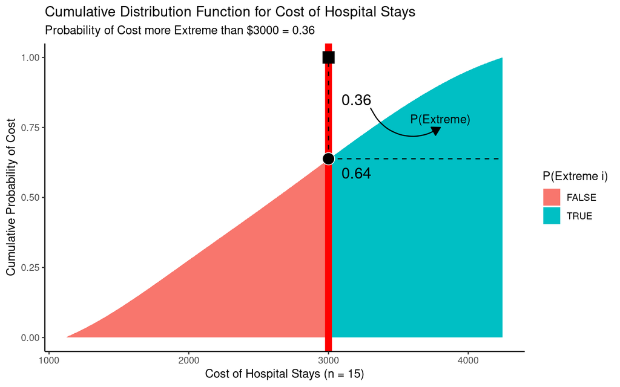

Figure 9. Visualizing a Cumulative Distribution Function!

```r
# View it!
viz_cd
# (Note: I've added some more annotation to mine
# than your image will have - don't worry!)
```

But wouldn’t it be handy if we could just make a literal cumulative distribution `function`, just like we did for the probability density `function` `dobs()`?

```r
pobs <- obs %>% density() %>% tidy() %>%
  # Sort from smallest to largest
  arrange(x) %>%
  # take cumulative sum, divided by total probability
  mutate(y = cumsum(y) / sum(y)) %>%
  # Make cumulative distribution function pobs()!
  approxfun()

# We'll test it out!
1 - pobs(3000)
```

```
## [1] 0.3726192
```

```r
# Pretty close to our probability we calculated before!
```

```r
# Clear unnecessary data.
remove(obs, stat, mypd, mycd, p, viz_cd)
```

# LC 2

## Question

A month has gone by, and our hospital has now billed 30 patients. You’ve heard that hospital bills at or above `$3000` a day may *somewhat* deter people from seeking future medical care, while bills at or above `$4000` may *greatly* deter people from seeking future care. (These numbers are hypothetical.)

Using the vectors below, please calculate the following, using a PDF or CDF.

- What’s the probability that a bill might *somewhat* deter a patient from going to the hospital?
- What’s the probability that a bill might *greatly* deter a patient from going to the hospital?
- What’s the probability that a patient might be *somewhat* deterred but **not** *greatly* deterred from going to the hospital?
- Note: Assume that the PDF matches the range of observed patients.

```r
# Let's record our vector of 30 patients
patients <- c(1126, 1493, 1528, 1713, 1912, 2060, 2541, 2612, 2888, 2915, 3166, 3552, 3692, 3695, 4248,
         3000, 3104, 3071, 2953, 2934, 2976, 2902, 2998, 3040, 3030, 3021, 3028, 2952, 3013, 3047)
# And let's get our statistics to compare against
somewhat <- 3000
greatly <- 4000
```

## Answer

```r
# Get the probability density function for our new data
dobs2 <- patients %>% density() %>% tidy() %>% approxfun()

# Get the probability densities
mypd2 <- tibble(
  cost = seq(min(patients), max(patients), by = 10),
  prob_cost_i = cost %>% dobs2()) %>%
  # Calculate probability of being somewhat deterred
  mutate(
    prob_somewhat_i = cost >= somewhat,
    prob_greatly_i = cost >= greatly,
    prob_somewhat_not_greatly_i = cost >= somewhat & cost < greatly)
```

To calculate these probabilities straight from the probability densities, do like so:

```r
mypd2 %>%
  summarize(
    # Calculate total probability of a cost somewhat deterring medical care
    prob_somewhat = sum(prob_cost_i * prob_somewhat_i) / sum(prob_cost_i),
    # Calculate total probability of a cost greatly deterring medical care
    prob_greatly = sum(prob_cost_i * prob_greatly_i) / sum(prob_cost_i),
    # Calculate total probability of a cost somewhat-but-not-greatly deterring medical care
    prob_somewhat_not_greatly = sum(prob_cost_i * prob_somewhat_not_greatly_i) / sum(prob_cost_i))
```

```
## # A tibble: 1 × 3
##   prob_somewhat prob_greatly prob_somewhat_not_greatly
##           <dbl>        <dbl>                     <dbl>
## 1         0.431       0.0172                     0.414
```

To calculate these probabilities from the cumulative distribution functions, we can do the following:

```r
# Get cumulative probabilities of each
mycd2 <- mypd2 %>%
  mutate(
    # Calculate total probability of a cost somewhat deterring medical care
    prob_somewhat = cumsum(prob_cost_i) * prob_somewhat_i / sum(prob_cost_i),
    # Calculate total probability of a cost greatly deterring medical care
    prob_greatly = cumsum(prob_cost_i) * prob_greatly_i / sum(prob_cost_i),
    # Calculate total probability of a cost somewhat-but-not-greatly deterring medical care
    prob_somewhat_not_greatly = cumsum(prob_cost_i) * prob_somewhat_not_greatly_i / sum(prob_cost_i))
# Check it!
mycd2 %>% tail(3)
```

```
## # A tibble: 3 × 8
##    cost prob_cost_i prob_somewhat_i prob_greatly_i prob_somewhat_not_greatly_i prob_somewhat prob_greatly prob_somewhat_not_g…¹
##   <dbl>       <dbl> <lgl>           <lgl>          <lgl>                               <dbl>        <dbl>                 <dbl>
## 1  4226    0.000106 TRUE            TRUE           FALSE                               0.998        0.998                     0
## 2  4236    0.000107 TRUE            TRUE           FALSE                               0.999        0.999                     0
## 3  4246    0.000107 TRUE            TRUE           FALSE                               1            1                         0
## # … with abbreviated variable name ¹prob_somewhat_not_greatly
```

Finally, if you want to visualize them, here’s how you would do it!

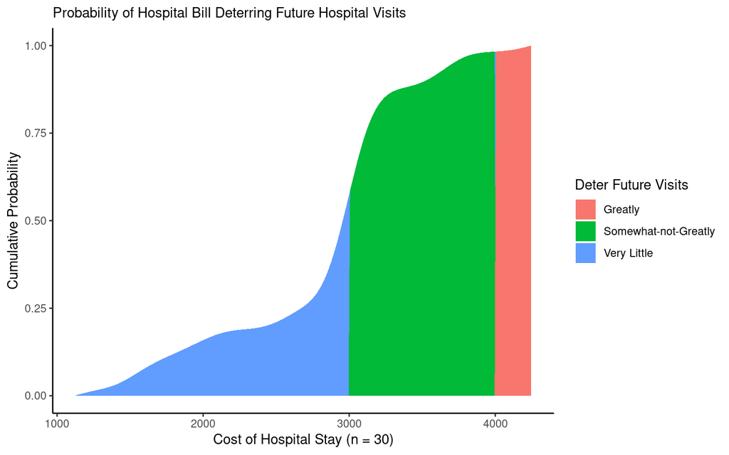

```r
ggplot() +
  # Get cumulative probability generally
  geom_area(data = mycd2, mapping = aes(x = cost, y = cumsum(prob_cost_i) / sum(prob_cost_i),
                                         fill = "Very Little")) +
  # Get cumulative probability if somewhat but not greatly
  geom_area(data = mycd2, mapping = aes(x = cost, y = prob_somewhat_not_greatly,
                                         fill = "Somewhat-not-Greatly")) +
  # Get cumulative probability if greatly
  geom_area(data = mycd2, mapping = aes(x = cost, y = prob_greatly,
                                         fill = "Greatly")) +
  theme_classic() +
  labs(x = "Cost of Hospital Stay (n = 30)",
       y = "Cumulative Probability",
       subtitle = "Probability of Hospital Bill Deterring Future Hospital Visits",
       fill = "Deter Future Visits")
```

# 3. Hypothetical Probability Functions

Often, though, our sample of data is just one of the many samples we could have possibly gotten; had we looked at a different hospital (by chance), or a different sample of patients come in by chance, we might have gotten slightly different hospital bills. The problem is, we almost never can see the distribution of the **true** population of all observations (eg. all hospital bills). But, if we can approximately guess *what type of distribution that population has*, we can very easily compute the probability density functions and cumulative distribution functions of several of the most well known distributions in `R` (eg. Normal, Poisson, Gamma, etc.)

## 3.1 Example: Farmers Market

The Ithaca Farmers Market is a vendor-owned cooperative that runs a massive Saturday-and-Sunday morning market for local produce, street food, and hand-made goods, on the waterfront of Cayuga Lake. In markets and street fairs, some stalls’ brands are often better known than others, so businesses new to the market might worry that people won’t come to their stalls without specific prompting. This past Saturday, a volunteer tracked 500 customers and recorded how many stalls each customers visited during their stay. They calculated the following statistics.

- The average customer visited a `mean` of `5.5` stalls and a `median` of `5` stalls, with a standard deviation of `2.5` stalls.

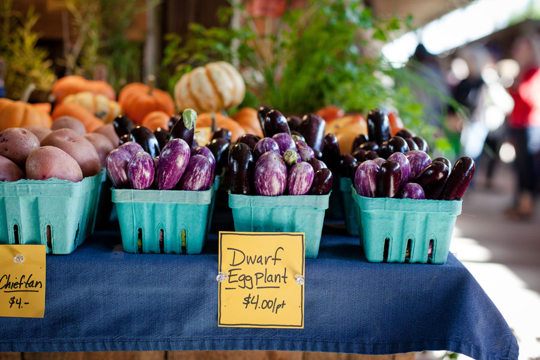

[Ithaca Farmers Market!](https://ithacamarket.com/markets/saturday-at-the-pavilion/)

Market operators wants to know:

1. What’s the probability that customers will stop by *5 stalls*?
2. What’s the probability that customers will stop by *at max 5 stalls*?
3. What’s the probability that customers will stop by *over 5 stalls*?
4. How many visits did people *usually* make? Estimate the interquartile range (25th-75th percentiles).

Unfortunately, the wind blew the raw data away into Cayuga Lake before they could finish their analysis. How can we approximate the unobserved distribution of visits and compute these probabilities?

Below, we will (1) use these statistics to guess which of several possible archetypal hypothetical distributions it most resembles, and then (2) compute probabilities based off of the shape of that hypothetical distribution.

## 3.2 Guessing the Shape of an Unobserved Distribution

We don’t have the actual data, but we know several basic features of our distribution!

- Our variable is `visits`, a count ranging from 0 to infinity. (Can’t have -5 visits, can’t have 1.3 visits.)
- The median (`5`) is less than the mean (`5.5`), so our distribution is **right-skewed**.

This sounds like a classic Poisson distribution! Let’s simulate some poisson-distributed data to demonstrate.

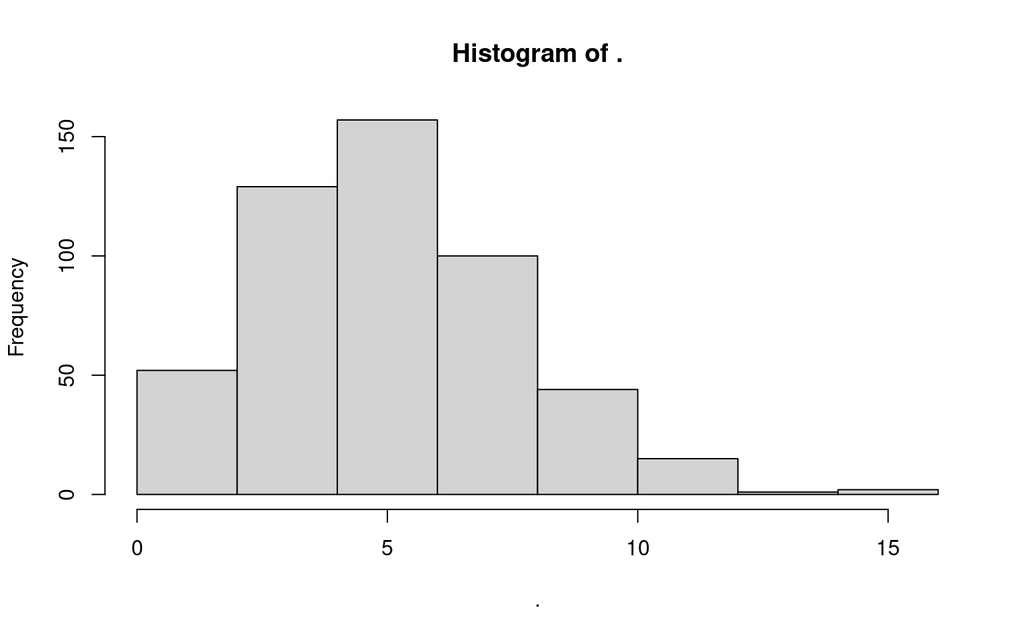

```r
# Randomly sample 500 visits from a poisson distribution with a mean of 5.5
visits <- rpois(n = 500, lambda = 5.5)
# Check out the distribution!
visits %>% hist()
```

## 3.3 Compute Probabilities using Hypothetical Distributions

Much like `rpois()` randomly generates poisson distributed values, `dpois()` generates the density of any value on a poisson distribution centered on a given mean, while `ppois()` returns for any percentile in the distribution the cumulative probability (percentage of the area under the density curve) up until that point.

Table 1: Probability Functions (r, d, p, and q)

| Meaning | Purpose | Main Input | Normal | Poisson | Gamma | Exponential |
| --- | --- | --- | --- | --- | --- | --- |
| Random Draws from Distribution | Simulate a distribution | n = # of simulations | rnorm() | rpois() | rgamma() | rexp() |
| Probability Density Function | Get Probability of Value in Distribution | x = value in distribution | dnorm() | dpois() | dgamma() | dexp() |
| Cumulative Distribution Function | Get % of Distribution LESS than Value | q = a cumulative probability | pnorm() | ppois() | pgamma() | pexp() |
| Quantiles Function | Get Value of any Percentile in Distribution | p = percentile | qnorm() | qpois() | qgamma() | qexp() |

## 3.4 Density

Below, `dpois()` tells us the `density()` or frequency of your value, given a distribution where the `mean = 5.5`.

```r
# Get the frequency for 5 visits in the distribution
pd5 <- dpois(5, lambda = 5.5)
# Check it!
pd5
```

```
## [1] 0.1714007
```

Looks like 17.1% of customers stopped by 5 stalls.

We can validate this using our simulated `visits` from above. We can calculate the `density()` function, extract it using `approxfun()`, and then assign it to `dsim()`, our own exact probability density function for our data. It works just like `dpois()`, but you don’t need to specify `lambda`, because it only works for this exact distribution!

```r
# Approximate the PDF of our simulated visits
dsim <- visits %>% density() %>% approxfun()
# Try our density function for our simulated data!
dsim(5)
```

```
## [1] 0.1584144
```

```r
# Pretty close to our results from dpois()!
```

## 3.5 Cumulative Probabilities

What percentage of customers stopped by *at max 5 stalls?*

```r
# Get the cumulative frequency for a value (5) in the distribution
cd5 <- ppois(q = 5, lambda = 5.5)
# Check it!
cd5
```

```
## [1] 0.5289187
```

What percentage of customers stopped by *over 5 stalls?*

```r
# Get the probability they will NOT stop at 5 or fewer stalls
1 - cd5
```

```
## [1] 0.4710813
```

We can validate our results against our simulated distribution.

```r
psim <- visits %>% density() %>% tidy() %>%
  # Get cumulative probability distribution
  arrange(x) %>%
  # Get cumulative probabilities
  mutate(y = cumsum(y) / sum(y)) %>%
  # Turn it into a literal function!
  approxfun()
# Check it!
psim(5)
```

```
## [1] 0.4438521
```

```r
# Pretty close to cdf5!
```

## 3.6 Quantiles

How many visits did people *usually* make? Estimate the interquartile range (25th-75th percentiles) of the unobserved distribution.

```r
q5 <- qpois(p = c(.25, .75), lambda = 5.5)
# Check it!
q5
```

```
## [1] 4 7
```

Looks like 50% of folks visited between 4 and 7 stalls

We can compare against our simulated data using `quantile()`.

```r
# Approximate the quantile function of this distribution
qsim <- tibble(
  # Get a vector of percentiles from 0 to 1, in units of 0.001
  x = seq(0, 1, by = 0.001),
  # Using our simulated distribution,
  # get the quantiles (values) at those points from this distribution
  y = visits %>% quantile(probs = x)) %>%
  # Approximate function!
  approxfun()

# Check it!
qsim(c(.25, .75))
```

```
## [1] 4 7
```

```r
rm(visits, pd5, cd5, q5, dsim, psim, qsim)
```

# LC 3

## Question

What if we are not certain whether our unobserved vector of visits has a Poisson distribution or not? To give you more practice, please calculate the probability that customers will stop *at more than 5 stalls*, using appropriate functions for the (1) Normal, (2) Gamma, and (3) Exponential distribution! (See our table above for the list of function names.)

## Answer

We know there were `n = 500` customers, with a mean of `5.5` visits, a median of `5` visits, and a standard deviation of `2.5` visits.

For a Normal Distribution:

We learned in Workshop 2 that `rnorm()` requires a `mean` and `sd` (standard deviation); we conveniently have both!

```r
1 - pnorm(5, mean = 5.5, sd = 2.5)
```

```
## [1] 0.5792597
```

For a Gamma Distribution:

We learned in Workshop 2 that `rgamma()` requires a `shape` and `scale` (or `rate`); we can calculate these from the `mean` and `sd` (standard deviation).

```r
# shape = mean^2 / variance = mean^2 / sd^2
shape <- 5.5^2 / 2.5^2
# scale = variance / mean
scale <- 2.5^2 / 5.5
# AND
# rate = 1 / scale
rate <- 1 / scale

# So...
# Get 1 - cumulative probability up to 5
1 - pgamma(5, shape = shape, scale = scale)
```

```
## [1] 0.5211581
```

```r
# OR (same)
1 - pgamma(5, shape = shape, rate = rate)
```

```
## [1] 0.5211581
```

For an Exponential Distribution:

We learned in Workshop 2 that `rexp()` requires a `rate`; we can calculate this from the `mean`.

```r
# For exponential distribution,
# rate = 1 / mean
rate <- 1 / 5.5

# So...
# Get 1 - cumulative probability up to 5
1 - pexp(5, rate = rate)
```

```
## [1] 0.4028903
```

And that’s a wrap! Nice work! You can now figure out *a lot* of things about the world if you (a) can guess their distribution and (b) have one or two statistics about that distribution. Here we go!